# Cryptocurrency Research Workshop

Dynamic Correlations and Volatility Spillovers

Kanis Saengchote

2025-04-26

# 1 Workshop Objectives

- Learn how to download and clean cryptocurrency and financial market data in R.
- Understand and estimate DCC-GARCH models for dynamic correlations.
- Measure volatility spillovers using the Diebold-Yilmaz framework.
- Visualize dynamic linkages between Bitcoin, Gold, S&P500, and NASDAQ.

# 2 Introduction

Cryptocurrencies like Bitcoin have become increasingly connected with traditional financial markets. Studying their dynamic relationships and volatility transmission is critical for:

- Portfolio diversification
- Risk management
- Understanding financial contagion.

In this workshop, we combine **time series modeling** with **network analysis** to investigate these connections using R. You do not need to download any data, since we will use the *quantmod* package to retrieve data from Yahoo Finance.

# 3 Load Required Libraries

```r
# Load libraries for the workshop
library(dplyr)        # Data manipulation (filter, mutate, summarise, etc.)
library(zoo)          # Advanced time series handling (irregular dates, merging)
library(quantmod)     # Download financial data from Yahoo Finance and handle OHLCV data
library(xts)          # Time series objects (especially financial time series)
library(rmgarch)      # Estimate multivariate GARCH models (including DCC-GARCH)
library(vars)         # Estimate Vector AutoRegression (VAR) models, used for spillover
library(igraph)       # Create network graphs based on correlations or connections
library(tidygraph)    # Tidy interface to igraph (works well with ggraph)
library(ggplot2)      # Create elegant plots based on the grammar of graphics
library(ggraph)       # Specialized plotting of network graphs (extending ggplot2)
library(scales)       # Pretty axis formatting for ggplot2 (percent, commas, etc.)
library(patchwork)    # Combine multiple ggplots into a single layout (stacking plots) analysis
```

# 4 Data Collection

We collect daily prices for:

- Bitcoin (BTC-USD)
- Gold (GC=F)
- S&P500 (^GSPC)
- NASDAQ (^IXIC)

*Note: the merged data will skip days when stock markets close.*

```r
# Define a list of asset tickers to download
tickers <- c("BTC-USD", "GC=F", "^GSPC", "^IXIC")
# BTC-USD: Bitcoin price from Yahoo Finance
# GC=F: Gold Futures price
# ^GSPC: S&P 500 index
# ^IXIC: NASDAQ index

# Download historical daily data from Yahoo Finance
getSymbols(tickers, src = "yahoo", from = "2018-01-01", to = Sys.Date())
```

```
## [1] "BTC-USD" "GC=F"    "GSPC"    "IXIC"
```

```r
# Data is stored as xts objects in the global environment

# Extract Adjusted Close prices for each asset
btc <- Cl(`BTC-USD`)   # Bitcoin adjusted close
gold <- Cl(`GC=F`)     # Gold adjusted close
sp500 <- Cl(`GSPC`)    # S&P500 adjusted close
nasdaq <- Cl(`IXIC`)   # NASDAQ adjusted close

# Merge all asset prices into one xts object
prices <- na.omit(merge(btc, gold, sp500, nasdaq))
# Remove any missing values with na.omit()

# Compute daily log returns and rename
returns <- na.omit(diff(log(prices)))
colnames(returns) <- c("Bitcoin", "Gold", "SP500", "NASDAQ")
# Log returns are more statistically stable and stationarity-friendly for modeling
```

✅ We use log returns because financial time series are better behaved statistically after log-differencing.

# 5 DCC-GARCH Model Estimation

## 5.1 What is DCC-GARCH?

The Dynamic Conditional Correlation Generalized Autoregressive Conditional Heteroskedasticity model (DCC-GARCH) is an econometric framework developed to jointly model time-varying volatility and time-varying correlations across multiple financial assets. It was proposed by Engle (2002) as a computationally feasible extension of multivariate GARCH models.

> Engle, R. (2002). Dynamic conditional correlation: A simple class of multivariate generalized autoregressive conditional heteroskedasticity models. *Journal of Business & Economic Statistics*, *20*(3), 339-350.

## 5.2 GARCH: Modeling Time-Varying Volatility

The GARCH (Generalized Autoregressive Conditional Heteroskedasticity) framework models how an asset’s conditional variance evolves over time, capturing features such as volatility clustering — the empirical observation that periods of high volatility tend to be followed by high volatility, and low volatility by low volatility.

In simple terms, GARCH explains how the volatility of each individual asset is changing based on its past shocks and volatility.

## 5.3 DCC: Modeling Time-Varying Correlations

While GARCH captures time-varying volatility at the univariate level, it does not, by itself, model how the relationships between assets change.

Dynamic Conditional Correlation (DCC) extends the framework by allowing the conditional correlations between asset returns to evolve over time as well.

Specifically, DCC separates the modeling into two stages:

- **Stage 1:** Estimate univariate GARCH models for each asset to standardize returns.
- **Stage 2:** Model the evolution of the standardized residuals’ correlation matrix dynamically over time.

The dynamic correlation matrix is updated recursively, capturing periods of financial contagion, decoupling, or clustering — important phenomena in financial markets.

## 5.4 Why Use DCC-GARCH?

- **Flexibility**: It allows for individual asset volatilities to behave differently (heteroskedasticity) while dynamically modeling how asset relationships change (correlation dynamics).
- **Computational Efficiency**: Compared to full multivariate GARCH models (like VECH or BEKK), DCC-GARCH dramatically reduces the number of parameters to estimate, making it feasible for portfolios of many assets.
- **Financial Relevance:** DCC-GARCH is crucial for risk management (e.g., Value-at-Risk aggregation), portfolio optimization, hedging strategies, and understanding financial contagion and systemic risk.

The DCC-GARCH model jointly captures time-varying second moments (volatilities) and conditional correlations in a multivariate setting. By disentangling the dynamics of volatilities from the dynamics of correlations, it offers a tractable yet rich framework to study the evolution of asset return interdependencies over time.

```r
# 1. Specify the univariate GARCH(1,1) model for each asset
uspec <- ugarchspec(
  mean.model = list(armaOrder = c(0,0)),            # No ARMA terms in the mean (pure returns)
  variance.model = list(model = "sGARCH",            # Standard GARCH model for volatility
                        garchOrder = c(1,1)),         # GARCH(1,1) structure (common and effective)
  distribution.model = "norm"                        # Assume normal distribution for errors
)

# 2. Specify the DCC (Dynamic Conditional Correlation) model
spec_dcc <- dccspec(
  uspec = multispec(replicate(4, uspec)),            # Replicate the univariate GARCH spec for 4 assets
  dccOrder = c(1,1),                                 # DCC(1,1): first-order dynamics in conditional correlation
  distribution = "mvnorm"                            # Multivariate normal distribution for joint returns
)

# 3. Fit the DCC-GARCH model to the return data
dcc_fit <- dccfit(spec_dcc, data = returns)
# This estimates both time-varying volatilities and time-varying correlations
```

# 6 Visualizing Average Correlations: DCC-GARCH Network

A DCC-GARCH network is a visualization and analysis tool where assets (nodes) are connected based on the dynamic conditional correlations estimated from a DCC-GARCH model. Instead of just looking at correlation matrices over time, the network approach helps reveal structural patterns — who is connected to whom, how strong those relationships are, and how these relationships evolve.

## 6.1 Nodes and Edges

- **Nodes** represent the individual assets (e.g., Bitcoin, S&P 500, Gold).
- **Edges** (connections between nodes) are drawn if the dynamic conditional correlation between two assets exceeds a certain threshold (e.g., correlation > 0.5).
- **Edge weights** may reflect the magnitude of the correlation: stronger correlations are depicted with thicker or darker lines.

## 6.2 Edge Weight and Sign

- **Positive correlations** typically indicate assets tend to move together (e.g., S&P 500 and NASDAQ).
- **Negative correlations** (if included) indicate inverse relationships (e.g., Gold vs. Equity indices during crisis).
- Some advanced DCC-network studies visualize signed networks, coloring positive and negative edges differently.

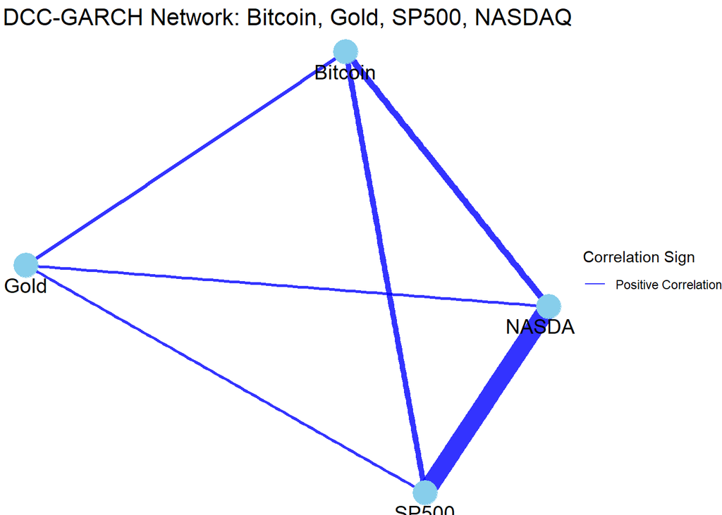

```r
# 1. Extract the full dynamic conditional correlation array from DCC-GARCH fit
correlations_array <- rcor(dcc_fit)
# correlations_array: 3-dimensional array (asset x asset x time)

# 2. Compute the time-averaged correlation matrix
avg_correlations <- apply(correlations_array, c(1,2), mean)
# Average across the time dimension to summarize overall correlations

# 3. Set diagonal elements (self-correlation) to 0
diag(avg_correlations) <- 0
# We are only interested in cross-asset correlations

# 4. Create an igraph network object from the correlation matrix
g <- graph_from_adjacency_matrix(
  avg_correlations,
  weighted = TRUE,
  mode = "undirected",
  diag = FALSE
)
# Edges represent the magnitude (and sign) of correlations between assets

# 5. Convert igraph to tidygraph and customize edge properties
tg <- as_tbl_graph(g) %>%
  activate(edges) %>%
  mutate(
    edge_sign = ifelse(weight > 0, "positive", "negative"),  # Assign edge type based on correlation sign
    edge_color = ifelse(weight > 0, "positive", "negative"), # Color edges by sign (blue = positive, red = negative)
    edge_width = abs(weight) * 8                             # Edge thickness proportional to correlation strength
  )

# 6. Plot the network using ggraph
ggraph(tg, layout = "fr") +  # Fruchterman-Reingold layout: forces nodes apart nicely
  geom_edge_link(aes(width = edge_width, color = edge_color), alpha = 0.8) +  # Draw edges with color and width
  geom_node_point(size = 8, color = "skyblue") +                               # Draw nodes (assets)
  geom_node_text(aes(label = name), vjust = 1.8, size = 5) +                   # Label nodes
  scale_edge_color_manual(
    values = c(positive = "blue", negative = "red"),                           # Blue = positive, Red = negative
    labels = c(positive = "Positive Correlation", negative = "Negative Correlation"),
    name = "Correlation Sign"                                                  # Legend title
  ) +
  theme_void() +                                                               # Clean background
  ggtitle("DCC-GARCH Network: Bitcoin, Gold, SP500, NASDAQ") +
  theme(plot.title = element_text(hjust = 0.5, size = 16)) +                   # Center title
  guides(edge_color = guide_legend(title = "Correlation Sign"), edge_width = FALSE)
```

# 7 Bitcoin vs NASDAQ: Dynamic Correlation

Let’s zoom into the Bitcoin-NASDAQ relationship over time.

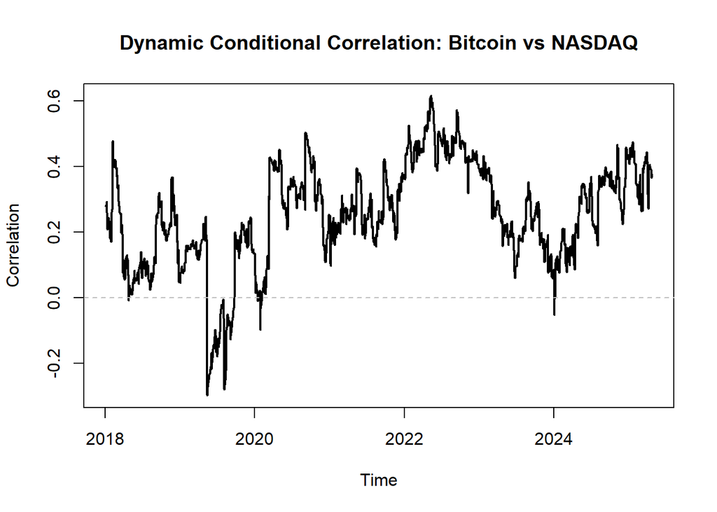

```r
# 1. Extract the time series of dynamic conditional correlation between Bitcoin and NASDAQ
dcc_bt_nasdaq <- correlations_array[1,4,]
# This selects:
# - 1st row (Bitcoin)
# - 4th column (NASDAQ)
# - all time points
# from the 3D correlation array

# 2. Convert the correlation series to a zoo time series object
dcc_bt_nasdaq_ts <- zoo(dcc_bt_nasdaq, order.by = index(returns))
# Attach proper date index (same as returns data)

# 3. Plot the dynamic conditional correlation over time
plot(dcc_bt_nasdaq_ts, type = "l", lwd = 2,
     main = "Dynamic Conditional Correlation: Bitcoin vs NASDAQ",
     ylab = "Correlation", xlab = "Time")
abline(h = 0, col = "gray", lty = 2)
```

```r
# Add a horizontal line at 0 to visually separate positive and negative correlations
```

✅ We can see whether Bitcoin and NASDAQ become more or less correlated during different market events.

DCC-GARCH shows correlation shifts over time, which can be useful for portfolio management.

# 8 Volatility Spillovers

Volatility spillovers refer to the phenomenon where **shocks** or **changes in volatility** in one market or asset transmit to another market or asset.

In other words, *instability is contagious*: when asset A becomes more volatile, it causes asset B to become more volatile as well — beyond what would be expected from asset B’s own fundamentals.

Volatility spillovers are grounded in theories of interconnected markets, information transmission, and investor behavior under uncertainty:

- **Market integration**: When markets are linked (through trade, finance, or sentiment), shocks propagate.
- **Information flows**: New information in one market can affect expectations in related markets.
- **Herding and panic**: Behavioral reactions can amplify volatility transmission, even across unrelated assets.

It is important to motivate the connectivity, since the volatility spillover analysis is a statistical exercise that *does not establish causality*. Academic roots often cite models like:

- **Engle’s ARCH and GARCH frameworks** for time-varying volatility. Look at how conditional correlations change when volatility spikes.
- **Diebold and Yilmaz (2014)**, who extended their earlier work on *returns connectedness* (2009, 2012) to focus specifically on *volatility spillovers*, using forecast error variance decompositions (FEVD) in vector autoregressions (VARs).

> Diebold, F. X., & Yilmaz, K. (2009). Measuring financial asset return and volatility spillovers, with application to global equity markets. *The Economic Journal*, *119*(534), 158-171.

> Diebold, F. X., & Yilmaz, K. (2012). Better to give than to receive: Predictive directional measurement of volatility spillovers. *International Journal of Forecasting*, *28*(1), 57-66.

> Diebold, F. X., & Yılmaz, K. (2014). On the network topology of variance decompositions: Measuring the connectedness of financial firms. *Journal of Econometrics*, *182*(1), 119-134.

Let’s use the Diebold-Yilmaz (2014) method. Because we extract conditional volatilities from a DCC-GARCH model, and estimate a VAR on volatilities, the spillover we are measuring is **volatility spillover** — not return spillover.

```r
# 1. Extract the conditional volatilities (standard deviations) from the DCC-GARCH model
cond_vol <- sigma(dcc_fit)
# cond_vol is a matrix: rows = time points, columns = assets

# 2. Rename the columns for easier interpretation
colnames(cond_vol) <- c("Bitcoin", "Gold", "SP500", "NASDAQ")

# 3. Convert to a data frame
vol_df <- as.data.frame(cond_vol)

# 4. Estimate a VAR model on the volatilities
var_model <- VAR(vol_df, p = 2, type = "const")
# p = 2 lags, include a constant term
# This models how today's volatility depends on past volatility shocks

# 5. Perform Forecast Error Variance Decomposition (FEVD)
fevd_result <- fevd(var_model, n.ahead = 10)
# Decompose forecast variance into contributions from own and others' shocks (10-step ahead horizon)

# 6. Build the FEVD matrix manually
fevd_matrix <- matrix(NA, 4, 4)
for (i in 1:4) {
  fevd_matrix[i,] <- fevd_result[[i]][10,]
}
# Each row: target asset
# Each column: source asset
# Element (i,j): percentage of asset i's volatility explained by shocks from asset j

# 7. Set the matrix row and column names
colnames(fevd_matrix) <- rownames(fevd_matrix) <- c("Bitcoin", "Gold", "SP500", "NASDAQ")

# 8. Normalize rows so each row sums to 100%
spillover_table <- fevd_matrix / rowSums(fevd_matrix) * 100
# Rows now represent percentage shares

# 9. Compute the Total Spillover Index (TSI)
tsi <- (sum(spillover_table) - sum(diag(spillover_table))) / sum(spillover_table) * 100
# TSI measures the overall amount of cross-market volatility transmission (off-diagonal contribution)

# 10. Output the spillover table and TSI
round(spillover_table, 2)   # Spillover Table: who influences whom
```

```
##         Bitcoin  Gold SP500 NASDAQ
## Bitcoin   97.43  0.00  1.21   1.35
## Gold       3.02 88.39  8.53   0.07
## SP500      7.98  1.83 89.01   1.17
## NASDAQ     7.42  1.04 86.42   5.12
```

```r
tsi                         # Total Spillover Index: overall interconnectedness
```

```
## [1] 30.01218
```

✅ Shocks to volatility in one asset can cause increases in volatility in another asset. The Total Spillover Index measures overall connectedness of the system. Of course, we can do this by sub-periods as well.

# 9 Rolling Total Spillover

We can compute a rolling spillover index to capture how spillovers change over time. (This will take a bit of time to run…)

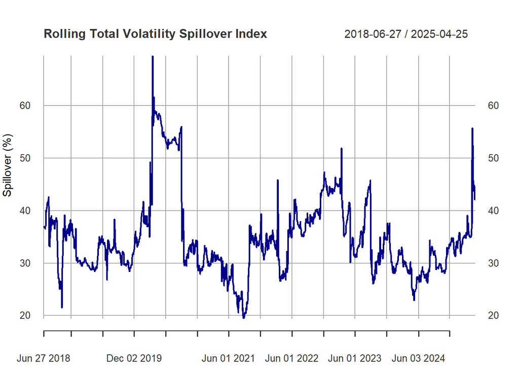

```r
# 1. Set the rolling window size
window_size <- 120
# 120 days ≈ 6 months — balances between smoothing and detecting changes

# 2. Initialize dimensions
n_obs <- nrow(vol_df)    # Total number of observations (days)
n_assets <- ncol(vol_df) # Number of assets (Bitcoin, Gold, SP500, NASDAQ)

# 3. Prepare an empty vector to store spillover index values
spillover_series <- rep(NA, n_obs - window_size)

# 4. Rolling window estimation
for (i in 1:(n_obs - window_size)) {

  # 4.1 Extract a rolling window of volatility data
  window_data <- vol_df[i:(i + window_size - 1), ]

  # 4.2 Fit a VAR model within the window
  var_model <- VAR(window_data, p = 2, type = "const")

  # 4.3 Forecast Error Variance Decomposition (FEVD)
  fevd_result <- fevd(var_model, n.ahead = 10)

  # 4.4 Build FEVD matrix for the window
  fevd_matrix <- matrix(NA, n_assets, n_assets)
  for (j in 1:n_assets) {
    fevd_matrix[j,] <- fevd_result[[j]][10,]  # Use 10-step ahead FEVD
  }

  # 4.5 Normalize rows so each row sums to 100
  fevd_matrix <- fevd_matrix / rowSums(fevd_matrix) * 100

  # 4.6 Calculate Total Spillover Index for this window
  spillover_series[i] <- (sum(fevd_matrix) - sum(diag(fevd_matrix))) / sum(fevd_matrix) * 100
}

# 5. Create a time series object for the rolling spillovers
spillover_xts <- xts(spillover_series, order.by = index(cond_vol)[(window_size+1):n_obs])

# 6. Plot the Rolling Total Volatility Spillover Index
plot(spillover_xts, type = "l", col = "darkblue", lwd = 2,
     main = "Rolling Total Volatility Spillover Index",
     ylab = "Spillover (%)", xlab = "Time")

# Add a horizontal red line for the mean spillover
abline(h = mean(spillover_series, na.rm = TRUE), col = "red", lty = 2)
```

✅ Rolling spillovers allow us to identify crisis periods where connectedness spikes.

# 10 Directional Spillovers: Bitcoin ➔ NASDAQ vs NASDAQ ➔ Bitcoin

We can also study who is influencing who over time.

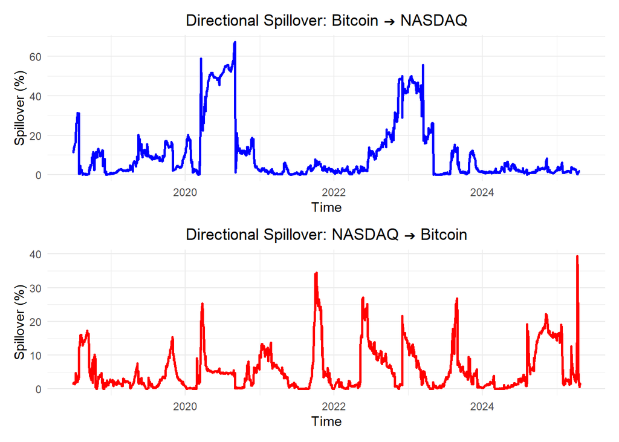

```r
# 1. Extract conditional volatilities for Bitcoin and NASDAQ
btc_vol <- cond_vol[,1]   # Bitcoin volatility
nasdaq_vol <- cond_vol[,4] # NASDAQ volatility

# 2. Merge the two volatilities into a single object
vol_pair <- na.omit(merge(btc_vol, nasdaq_vol))
colnames(vol_pair) <- c("Bitcoin", "NASDAQ")
# Clean and name the series

# 3. Initialize parameters for rolling window analysis
n_obs <- nrow(vol_pair)        # Total number of observations
btc_to_nasdaq <- rep(NA, n_obs - window_size) # Empty vector to store results
nasdaq_to_btc <- rep(NA, n_obs - window_size)

# 4. Rolling window estimation of directional spillovers
for (i in 1:(n_obs - window_size)) {

  # 4.1 Extract rolling window slice
  window_data <- vol_pair[i:(i + window_size - 1), ]

  # 4.2 Fit VAR(2) model
  var_model <- VAR(window_data, p = 2, type = "const")

  # 4.3 Forecast Error Variance Decomposition (FEVD)
  fevd_result <- fevd(var_model, n.ahead = 10)

  # 4.4 Build FEVD matrix
  fevd_matrix <- matrix(NA, 2, 2)
  for (j in 1:2) {
    fevd_matrix[j,] <- fevd_result[[j]][10,]
  }

  # 4.5 Normalize rows to sum to 100
  fevd_matrix <- fevd_matrix / rowSums(fevd_matrix) * 100

  # 4.6 Extract directional spillovers
  btc_to_nasdaq[i] <- fevd_matrix[2,1]  # Bitcoin's impact on NASDAQ
  nasdaq_to_btc[i] <- fevd_matrix[1,2]  # NASDAQ's impact on Bitcoin
}

# 5. Create xts time series objects for plotting
btc_nasdaq_xts <- xts(btc_to_nasdaq, order.by = index(vol_pair)[(window_size+1):n_obs])
nasdaq_btc_xts <- xts(nasdaq_to_btc, order.by = index(vol_pair)[(window_size+1):n_obs])

# 6. Combine into a tidy data frame for ggplot2
spillover_df <- data.frame(
  Date = index(btc_nasdaq_xts),
  BTC_to_NASDAQ = coredata(btc_nasdaq_xts),
  NASDAQ_to_BTC = coredata(nasdaq_btc_xts)
)

# 7. Plot 1: Bitcoin ➔ NASDAQ Spillover
p1 <- ggplot(spillover_df, aes(x = Date, y = BTC_to_NASDAQ)) +
  geom_line(color = "blue", size = 1) +
  labs(title = "Directional Spillover: Bitcoin ➔ NASDAQ",
       x = "Time", y = "Spillover (%)") +
  theme_minimal() +
  theme(plot.title = element_text(hjust = 0.5))

# 8. Plot 2: NASDAQ ➔ Bitcoin Spillover
p2 <- ggplot(spillover_df, aes(x = Date, y = NASDAQ_to_BTC)) +
  geom_line(color = "red", size = 1) +
  labs(title = "Directional Spillover: NASDAQ ➔ Bitcoin",
       x = "Time", y = "Spillover (%)") +
  theme_minimal() +
  theme(plot.title = element_text(hjust = 0.5))

# 9. Stack the two plots vertically using patchwork
p1 / p2
```

✅ This shows dynamic leadership between Bitcoin and NASDAQ volatility.

# 11 Return Spillover Analysis: Bitcoin ➔ NASDAQ vs NASDAQ ➔ Bitcoin

When studying financial connectedness, it is important to distinguish between price movements and risk transmission.

Return spillover analysis focuses on how price changes in one asset directly influence price changes in another asset. In this framework, we are interested in information transmission across markets:

- **Leadership and lagging behavior** between assets,
- **Predictability of returns**,
- **How shocks to fundamentals or sentiment in one market propagate into others.**

Analyzing return spillovers is especially valuable when:

- Studying **market integration** or **segmentation**,
- Identifying **information flows** during **normal time**,
- Exploring **price discovery dynamics** across assets,
- Understanding **crypto vs traditional asset relationships**.

Unlike volatility spillovers, which focus on **risk transmission**, return spillovers map **the transmission of economic shocks and trading information**.

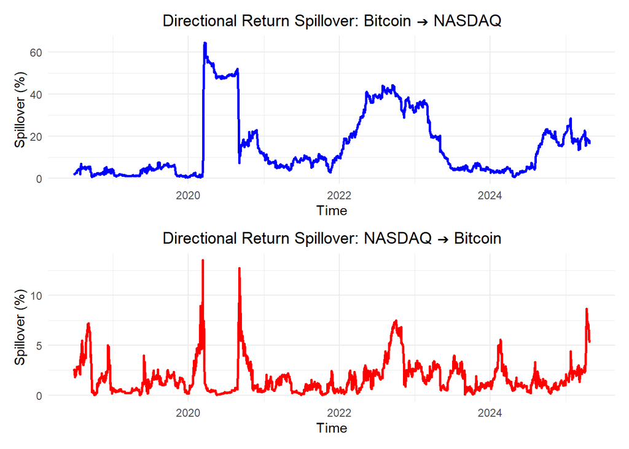

```r
# 1. Extract returns for Bitcoin and NASDAQ
btc_return <- returns[,1]    # Bitcoin returns
nasdaq_return <- returns[,4] # NASDAQ returns

# 2. Merge the two return series into a single object
return_pair <- na.omit(merge(btc_return, nasdaq_return))
colnames(return_pair) <- c("Bitcoin", "NASDAQ")
# Clean and name the series

# 3. Initialize parameters for rolling window analysis
n_obs <- nrow(return_pair)          # Total number of observations
btc_to_nasdaq <- rep(NA, n_obs - window_size)  # Empty vector to store results
nasdaq_to_btc <- rep(NA, n_obs - window_size)

# 4. Rolling window estimation of directional return spillovers
for (i in 1:(n_obs - window_size)) {

  # 4.1 Extract rolling window slice
  window_data <- return_pair[i:(i + window_size - 1), ]

  # 4.2 Fit VAR(2) model
  var_model <- VAR(window_data, p = 2, type = "const")

  # 4.3 Forecast Error Variance Decomposition (FEVD)
  fevd_result <- fevd(var_model, n.ahead = 10)

  # 4.4 Build FEVD matrix
  fevd_matrix <- matrix(NA, 2, 2)
  for (j in 1:2) {
    fevd_matrix[j,] <- fevd_result[[j]][10,]
  }

  # 4.5 Normalize rows to sum to 100
  fevd_matrix <- fevd_matrix / rowSums(fevd_matrix) * 100

  # 4.6 Extract directional return spillovers
  btc_to_nasdaq[i] <- fevd_matrix[2,1]  # Bitcoin's return impact on NASDAQ
  nasdaq_to_btc[i] <- fevd_matrix[1,2]  # NASDAQ's return impact on Bitcoin
}

# 5. Create xts time series objects for plotting
btc_nasdaq_xts <- xts(btc_to_nasdaq, order.by = index(return_pair)[(window_size+1):n_obs])
nasdaq_btc_xts <- xts(nasdaq_to_btc, order.by = index(return_pair)[(window_size+1):n_obs])

# 6. Combine into a tidy data frame for ggplot2
spillover_df <- data.frame(
  Date = index(btc_nasdaq_xts),
  BTC_to_NASDAQ = coredata(btc_nasdaq_xts),
  NASDAQ_to_BTC = coredata(nasdaq_btc_xts)
)

# 7. Plot 1: Bitcoin ➔ NASDAQ Return Spillover
p1 <- ggplot(spillover_df, aes(x = Date, y = BTC_to_NASDAQ)) +
  geom_line(color = "blue", size = 1) +
  labs(title = "Directional Return Spillover: Bitcoin ➔ NASDAQ",
       x = "Time", y = "Spillover (%)") +
  theme_minimal() +
  theme(plot.title = element_text(hjust = 0.5))

# 8. Plot 2: NASDAQ ➔ Bitcoin Return Spillover
p2 <- ggplot(spillover_df, aes(x = Date, y = NASDAQ_to_BTC)) +
  geom_line(color = "red", size = 1) +
  labs(title = "Directional Return Spillover: NASDAQ ➔ Bitcoin",
       x = "Time", y = "Spillover (%)") +
  theme_minimal() +
  theme(plot.title = element_text(hjust = 0.5))

# 9. Stack the two plots vertically using patchwork
p1 / p2
```

> **Today, volatility spillover analysis is more popular in academic and professional research, especially in studies of systemic risk. Volatility spillovers dominate most contagion, financial stability, and crypto risk research papers.**

# 12 Conclusion: Understanding Dynamic Interconnectedness

In this workshop, we explored how to use R for analyzing cryptocurrency and traditional assets through dynamic correlation and volatility spillover frameworks.

Specifically, we learned how to:

1. Download and prepare financial and crypto data from Yahoo Finance,
2. Estimate DCC-GARCH models to track time-varying correlations,
3. Visualize relationships between Bitcoin, Gold, SP500, and NASDAQ,
4. Measure total volatility spillovers using the Diebold-Yilmaz framework,
5. Compare transmission roles between Bitcoin and NASDAQ over time.

**⚠️ Important: These Tools Measure Connectivity, Not Causality ⚠️**

It is crucial to emphasize that DCC-GARCH and volatility spillover analysis reveal **statistical connectedness**, but **do not establish causality**.

- High **correlation** does not mean one asset **causes** movements in another.
- Spillover indexes tell us that shocks propagate between markets — but **not the underlying reasons why**.
- **No causal inference** can be drawn from simple correlation-based frameworks.

Thus, while these tools are essential first steps in uncovering market interdependence, they should be complemented with economic reasoning and causal modeling approaches (e.g., Structural VARs, Granger causality tests, or external instrumental variables) when making claims about economic mechanisms.